# Modelling workshop: Session 1

### Session 1b - Data types and data manipulation in R

R has several **data types** that are used to store and manipulate data. What follows are some of the most commonly used data types in R. We will use a few new functions as we go through this and introduce them as we go.

**Numeric** data represent real numbers and are used to store continuous numerical data, such as measurements or counts. For example,

```r
# Simulate data
set.seed(123) # Set seed for reproducibility
data <- rnorm(5, mean = 10, sd = 2)

# Print data
print(data)
```

```
## [1]  8.879049  9.539645 13.117417 10.141017 10.258575
```

In this script, **rnorm()** is used to simulate a normal distribution with a mean of 10 and a standard deviation of 2, generating 5 random values. The **set.seed()** function is used to ensure reproducibility of the results. The **print()** function is one we already learned above and used to display the generated data in the console. Note that the object **data** now contains a new dataset to when we used it above.

You can modify the parameters of **rnorm()** to generate different types of data sets with different distributions and parameters.

**Integer** data represent *whole numbers* and are used to store discrete numerical data, such as counts or indices. For example,

```r
# Simulate data
set.seed(123) # Set seed for reproducibility
data <- sample(1:10, 5, replace = TRUE)

# Print data
print(data)
```

```
## [1]  3  3 10  2  6
```

In this script, **sample()** is used to randomly select 5 *integers* from the range of 1 to 10 with replacement (i.e. you can sample the same number more than once). The **set.seed()** and **print()** functions are used to ensure reproducibility of the results and display the results as before.

You can modify the parameters of **sample()** to generate different types of data sets with different ranges and sizes.

**Character** data types in R represent *strings* of **text** and are used to store categorical or textual data. For example,

```r
# Simulate data
data <- c("red", "blue", "green", "yellow", "orange")

# Print data
data
```

```
## [1] "red"    "blue"   "green"  "yellow" "orange"
```

In this script, a **character** *vector* is created with 5 different color names. Note that here we printed the data without using the **print()** function. This is a common short cut.

### Logical data and conditions

**Logical** data types in R represent *Boolean* values (i.e. only two values) and are used to store binary data, such as **true/false** values or logical conditions. For example,

```r
# Define logical variables
var1 <- TRUE
var2 <- FALSE

# Define a logical vector
vector1 <- c(TRUE, FALSE, TRUE, FALSE, TRUE)

# Perform logical functions
result1 <- any(vector1) # returns TRUE if any element in vector1 is TRUE
result2 <- all(vector1) # returns TRUE if all elements in vector1 are TRUE
result3 <- xor(var1, var2) # returns TRUE if either var1 or var2 is TRUE, but not both

# Print results
print(result1)
```

```
## [1] TRUE
```

```r
print(result2)
```

```
## [1] FALSE
```

```r
print(result3)
```

```
## [1] TRUE
```

In this script, two **logical** variables *var1* and *var2* are defined with the values **TRUE** and **FALSE**, respectively. A logical vector called *vector1* is also defined with 5 values.

Three logical functions are then performed:

The **any()** function checks if any element in *vector1* is **TRUE** and returns a logical value. The result is saved in the *result1* variable.

The **all()** function checks if all elements in *vector1* are **TRUE** and returns a logical value. The result is saved in the *result2* variable.

The **xor()** function checks if either *var1* or *var2* is **TRUE**, *but not both*, and returns a logical value. The result is saved in the *result3* variable.

Next, we will try a different way of looking at this:

```r
# Define logical variables
var1 <- TRUE
var2 <- FALSE

# Print logical variables
print(var1)
```

```
## [1] TRUE
```

```r
print(var2)
```

```
## [1] FALSE
```

```r
# Perform logical operations
result1 <- var1 & var2 # AND operator
result2 <- var1 | var2 # OR operator
result3 <- !var1 # NOT operator

# Print results
print(result1)
```

```
## [1] FALSE
```

```r
print(result2)
```

```
## [1] TRUE
```

```r
print(result3)
```

```
## [1] FALSE
```

In this script, **logical** variables *var1* and *var2* are defined with the values **TRUE** and **FALSE**, respectively. The **print()** function is used as before.

**Logical** operations are then performed using the **&** (AND), **|** (OR), and **!** (NOT) operators on the logical variables.

#### Warning on R syntax

This is also a good place to note two other important R syntax points.

##### Upper case, lower case, …

R treats capital (or *upper case*) letters differently to *lower case*, so **A** is **not** the same as **a**. This means that if you have a vector of characters or factors with *Apple* and *apple*, these are different. Similarly if you import a dataset that has a *space* before or after a word, it is different. So, ’ Cow’ is not the same as ‘Cow’ is not the same as ’ cow’ or ‘cow’ to R. This encourages you to enter and keep clean data.

##### Assignment operators

Also, you can also assign things using the **=** sign instead of the *assignment operator* **<-**. I tend not to do this because $==$ means something else and can be mistaken for $=$. So lets do one exercise to test this:

```r
a <- 1 # assign the number 1 to a
A <- 2 # assign the number 2 to A
print(a)
```

```
## [1] 1
```

```r
print(A)
```

```
## [1] 2
```

```r
A==a
```

```
## [1] FALSE
```

```r
# now use the = as asign
A=a
print(a)
```

```
## [1] 1
```

```r
print(A)
```

```
## [1] 1
```

```r
A==a
```

```
## [1] TRUE
```

This can sometimes cause some confusion, so let’s try with another example of logical conditions:

```r
# Define variables
var1 <- 10
var2 <- 5

# Perform logical conditions
result1 <- var1 > var2 # asks if var1 is greater than var2
result2 <- var1 < var2
result3 <- var1 == var2
result4 <- var1 != var2

# Print results
print(result1)
```

```
## [1] TRUE
```

```r
print(result2)
```

```
## [1] FALSE
```

```r
print(result3)
```

```
## [1] FALSE
```

```r
print(result4)
```

```
## [1] TRUE
```

In this script, two *variables* *var1* and *var2* are defined with the values 10 and 5, respectively.

**Logical** conditions are then performed using the **>**, **<**, **==**, and **!=** operators on the variables. The **>** operator checks if *var1* is greater than *var2*, the **<** operator checks if *var1* is less than *var2*, the **==** operator checks if *var1* is equal to *var2*, and the **!=** operator checks if *var1* is not equal to *var2*. The results of each condition are saved in separate variables *result1*, *result2*, *result3*, and *result4*.

Note that we can check the type of data these variables are by using the **class()** function.

```r
class(var1)
```

```
## [1] "numeric"
```

```r
class(var2)
```

```
## [1] "numeric"
```

#### Factors

**Factor** data types in R represent categorical data with a fixed set of **levels**. Factors are often used to represent categorical variables in statistical analyses. For example:

```r
# Define a factor variable
var1 <- factor(c("A", "B", "A", "C", "B", "B", "C", "C", "A"))

# Define a numeric variable
var2 <- c(10, 20, 15, 25, 30, 35, 23, 25, 12)

# Combine variables into a data frame
df <- data.frame(var1, var2)

# Print the data frame
print(df)
```

```
##   var1 var2
## 1    A   10
## 2    B   20
## 3    A   15
## 4    C   25
## 5    B   30
## 6    B   35
## 7    C   23
## 8    C   25
## 9    A   12
```

In this script, a **factor** variable *var1* is defined with 9 values representing 3 different **levels**: “A”, “B”, and “C”. A **numeric** variable *var2* is also defined with 9 values.

The two variables are then combined into a **data frame** called *df* using the **data.frame()** function. We will discuss data frames below. Note we can plot this data set using:

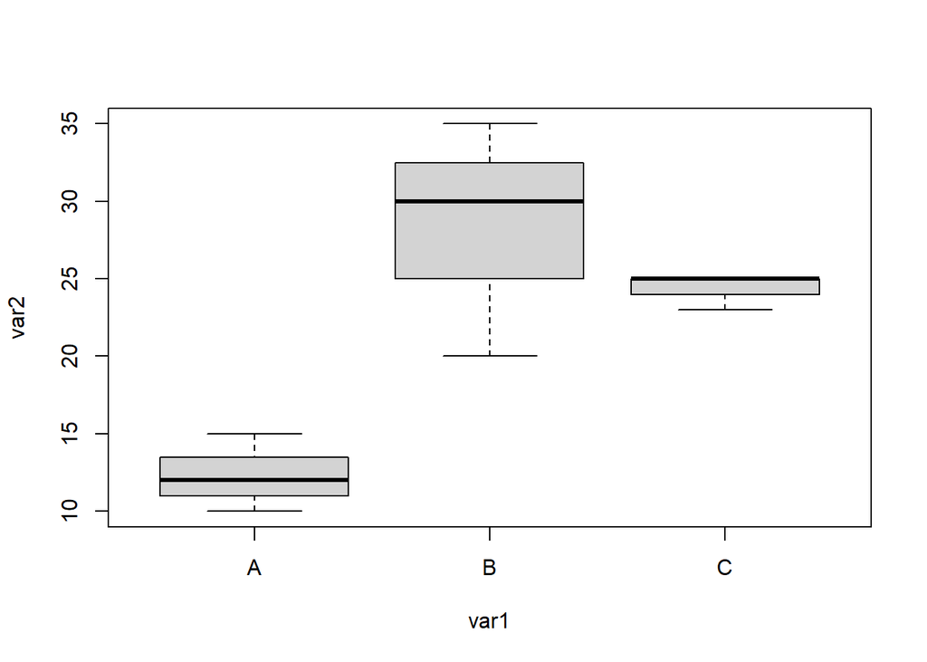

```r
plot(df)
```

Depending on the data and the data structure, the default **plot()** function will plot different plots. This is a **box-and-whisker** plot showing the *median* (black bar); the *interquartile range* (grey box) with the *upper* and *lower* *quartiles* and the *highest* and *lowest* values as the end bars. Note sometimes there are outliers that show as individual points. We will come back to these later in the workshop.

#### Times and dates

R has built-in data types for storing and manipulating **dates** and **times**. These data types are useful for time series analysis and data visualization. Let’s create some data to begin with using this code:

```r
# Create a date sequence for the month of May 2023
dates <- seq(as.Date("2023-05-01"), as.Date("2023-05-31"), by = "day")

# Create a time sequence for the day, in 45-minute intervals
times <- seq(from = as.POSIXct("2023-05-01 00:00:00"), to = as.POSIXct("2023-05-01 23:45:00"), by = "45 min")

# Print the first 10 dates
print(head(dates, n = 10))
```

```
##  [1] "2023-05-01" "2023-05-02" "2023-05-03" "2023-05-04" "2023-05-05"
##  [6] "2023-05-06" "2023-05-07" "2023-05-08" "2023-05-09" "2023-05-10"
```

```r
print(head(times, n = 10))
```

```
##  [1] "2023-05-01 00:00:00 NZST" "2023-05-01 00:45:00 NZST"
##  [3] "2023-05-01 01:30:00 NZST" "2023-05-01 02:15:00 NZST"
##  [5] "2023-05-01 03:00:00 NZST" "2023-05-01 03:45:00 NZST"
##  [7] "2023-05-01 04:30:00 NZST" "2023-05-01 05:15:00 NZST"
##  [9] "2023-05-01 06:00:00 NZST" "2023-05-01 06:45:00 NZST"
```

In this script, a *sequence* of **dates** is created using the **seq()** function, with the *start* and *end* dates specified using the **as.Date()** function. The **by** parameter is set to **“day”** to generate a sequence of dates, one for each day in May 2023.

Note that **lubridate** is a nice way to deal with times and dates in the **tidyverse** syntax that we will come to. You can find this here for later: https://lubridate.tidyverse.org/

We can plot time and date data too. Here’s an example of some code, simulating data from a different time period for practice and to show you another data series and here we will plot it with **ggplot()**:

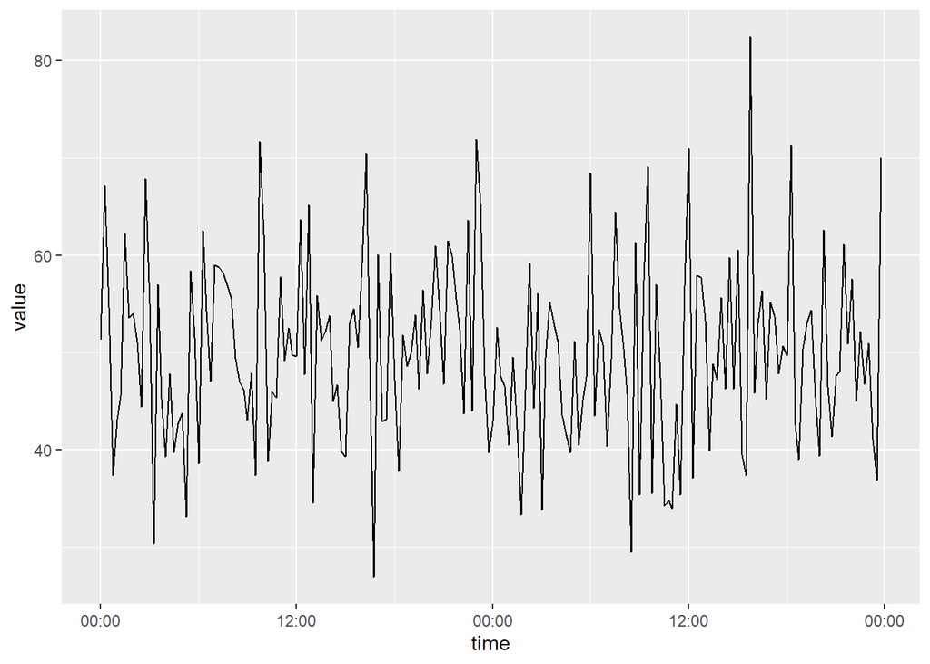

```r
# Generate some time data
time <- seq(as.POSIXct("2022-01-01 00:00:00"), as.POSIXct("2022-01-02 23:59:59"), by = "15 min")
value <- rnorm(length(time), mean = 50, sd = 10)
data <- data.frame(time, value)

# Plot the data using ggplot2
library(ggplot2)
ggplot(data, aes(x = time, y = value)) +
  geom_line() +
  scale_x_datetime(date_labels = "%H:%M")
```

This script first generates some time data using the **seq()** function to create a sequence of 15-minute intervals between January 1st and January 2nd, 2022. The **rnorm()** function is then used to generate some random values for each time point using **length(time)**. The data is then stored in a *data frame* called *data*.

The script then loads the **ggplot2** **library** and creates a plot of the data using **ggplot()**. We will cover **ggplot()** more later, but let’s introduce the terms; the **aes()** function is used to specify that the x-axis should be the *time* variable and the y-axis should be the *value* variable. The **geom_line()** function is used to draw a line connecting the data points. Finally, the **scale_x_datetime()** function is used to format the x-axis labels as hours and minutes.

#### Lists

**Lists** in R are used to store complex or structured data, such as nested data frames or ‘’heterogeneous’’ data sets.

```r
# Create a list
my_list <- list(
  name = "Bat 1",
  age = 6,
  seropositive = TRUE,
  signs = c("dark marking", "banded")
)

# Access elements of the list
my_list$name
```

```
## [1] "Bat 1"
```

```r
my_list$age
```

```
## [1] 6
```

```r
my_list$seropositive
```

```
## [1] TRUE
```

```r
my_list$signs
```

```
## [1] "dark marking" "banded"
```

```r
# Add an element to the list
my_list$new_element <- "This is a new element"

# check out the new element
names(my_list)
```

```
## [1] "name"         "age"          "seropositive" "signs"        "new_element"
```

```r
# Remove an element from the list
my_list$age <- NULL

# check the removal of 'age'
names(my_list)
```

```
## [1] "name"         "seropositive" "signs"        "new_element"
```

Lists can be very useful but they are also not the most intuitive objects to work with. Let’s take one look at the structure of the list using the **str()** function and use two ways to find the `Bat 1’ character:

```r
str(my_list)
```

```
## List of 4
##  $ name        : chr "Bat 1"
##  $ seropositive: logi TRUE
##  $ signs       : chr [1:2] "dark marking" "banded"
##  $ new_element : chr "This is a new element"
```

```r
# method one
my_list$name[1]
```

```
## [1] "Bat 1"
```

```r
# method two
my_list[[1]][1]
```

```
## [1] "Bat 1"
```

We will discuss these approaches to indexing more in the next section on arrays and matrices.